# Data loading and visualizations

This is the first notebook used in the speed of sound prediction experiment. It loads all input CSV files. There are several data visualization functions in the second part of the notebook.

```python
# dependencies

import pandas as pd
import numpy as np
import matplotlib as mpl
from matplotlib import pyplot as plt
import sys
import os

%matplotlib inline
```

## Definition of all chemistry related variables

All used chemical names and properties are definied to be used later in code

```python
# lists storing used ionic species

cations = ["Na", "K", "Li", "NH4", "H"]
anions = ["Br","Cl", "I", "2SO4", "2CO3", "NO3", "OH"]
```

```python
# dictionary converting species to its textual representation
# with super / subscripts

chem_repr = {"Na" : r'$\mathrm{Na}^+$',
             "K" : r'$\mathrm{K}^+$',
             "NH4" : r'$\mathrm{NH}_4^+$',
             "Li" : r'$\mathrm{Li}^+$',
             "H" : r'$\mathrm{H}^+$',
             "Br" : r'$\mathrm{Br}^-$',
             "Cl" : r'$\mathrm{Cl}^-$',
             "I" : r'$\mathrm{I}^-$',
             "2SO4" : r'$\mathrm{SO}_4^{2-}$',
             "2CO3" : r'$\mathrm{CO}_3^{2-}$',
             "NO3" : r'$\mathrm{NO}_3^-$',
             "OH" : r'$\mathrm{OH}^-$'}
```

```python
# experimental dimensions
parameters = ["T", "sound", "c"]
```

```python
# units for for all experimental physical dimensions
units = {"T":"K", "c": "mol/kg", "sound": "m/s"}
```

## Load CSV files into pandas DataFrames

CSV files are loaded from the `data/` directory. The electrolyte names are created by concatenation of cation and anion names and have the following format: `water_electrolyte.csv`.

```python
# the file path to csv files
# current working directory must be the notebook's directory
# if it is not use os.chdir(path) to set it there

file_path = r"../data/"
```

**Helper functions for data loading**

```python
def csv_read(filename):
    """
    Loads CSV file. Filename is the path to file.
    Returns CSV contents as pandas DataFrame.
    Accepts ',' or ';' separators.
    First row is header, next two are skipped.
    First column is index.
    """

    try:
        with open(filename, 'r') as csv:
            df = pd.read_csv(csv,header=0, sep = "[,;]",
                             skiprows = [1,2], index_col=0)

    except FileNotFoundError:
        print("{0} does not exist".format(filename))
    except:
        print("Unexpected error with {0}: {1}"
              .format(filename, sys.exc_info()[0]))
    else:
        return df
```

```python
def cation_anion_switch(element):
    """
    Returns anions list for cation and vice versa.
    """

    if element in cations:
        return anions
    elif element in anions:
        return cations
    else:
        raise NameError("Unknown element {0}".format(element))
```

```python
def load_by_ion(ion):
    """
    Loads and creates list of all dataframes containing input ion.
    Empty dataframe is inserted for nonavailable
    cation/anion combination.
    Files are loaded from file_path folder.
    """

    counterions = cation_anion_switch(ion)
    path = file_path + r"water_"
    list = []
    empty_df = pd.DataFrame()

    for i in counterions:

        # check ion identity to produce correct filename
        if ion in cations:
            filename = path + ion + i + ".csv"
        else:
            filename = path + i + ion + ".csv"

        if os.path.exists(filename):
            list.append(csv_read(filename))
        else:
            print("{0} does not exist".format(filename))
            list.append(empty_df)

    return list
```

### Load all datasets

```python
NH4 = load_by_ion("NH4")
Na = load_by_ion("Na")
K = load_by_ion("K")
Li = load_by_ion("Li")
H = load_by_ion("H")
```

```
../data/water_NH4I.csv does not exist
../data/water_NH42CO3.csv does not exist
../data/water_LiI.csv does not exist
../data/water_Li2CO3.csv does not exist
../data/water_HBr.csv does not exist
../data/water_HI.csv does not exist
../data/water_H2SO4.csv does not exist
../data/water_H2CO3.csv does not exist
```

```python
# stores all DataFrames as a list of lists of DataFrames
# each for one cation
all_cation_dfs = [Na, K, Li, NH4, H]
```

```python
Cl = load_by_ion("Cl")
Br = load_by_ion("Br")
I = load_by_ion("I")
SO4 = load_by_ion("2SO4")
CO3 = load_by_ion("2CO3")
NO3 = load_by_ion("NO3")
OH = load_by_ion("OH")
```

```
../data/water_HBr.csv does not exist
../data/water_LiI.csv does not exist
../data/water_NH4I.csv does not exist
../data/water_HI.csv does not exist
../data/water_H2SO4.csv does not exist
../data/water_Li2CO3.csv does not exist
../data/water_NH42CO3.csv does not exist
../data/water_H2CO3.csv does not exist
```

```python
# stores all DataFrames as a list of lists of DataFrames
# each for one anion
all_anion_dfs = [Br, Cl, I, SO4, CO3, NO3, OH]
```

```python
# print dataset sizes for all considered electrolytes

for cation, dfs in zip(cations, all_cation_dfs):
    for anion, df in zip(anions, dfs):
        print("Size of {0}{1} dataset: {2}".format(cation, anion, df.shape[0]))
```

```
Size of NaBr dataset: 228
Size of NaCl dataset: 228
Size of NaI dataset: 226
Size of Na2SO4 dataset: 138
Size of Na2CO3 dataset: 160
Size of NaNO3 dataset: 228
Size of NaOH dataset: 160
Size of KBr dataset: 228
Size of KCl dataset: 228
Size of KI dataset: 228
Size of K2SO4 dataset: 73
Size of K2CO3 dataset: 31
Size of KNO3 dataset: 228
Size of KOH dataset: 132
Size of LiBr dataset: 187
Size of LiCl dataset: 138
Size of LiI dataset: 0
Size of Li2SO4 dataset: 7
Size of Li2CO3 dataset: 0
Size of LiNO3 dataset: 300
Size of LiOH dataset: 125
Size of NH4Br dataset: 9
Size of NH4Cl dataset: 8
Size of NH4I dataset: 0
Size of NH42SO4 dataset: 120
Size of NH42CO3 dataset: 0
Size of NH4NO3 dataset: 5
Size of NH4OH dataset: 102
Size of HBr dataset: 0
Size of HCl dataset: 49
Size of HI dataset: 0
Size of H2SO4 dataset: 0
Size of H2CO3 dataset: 0
Size of HNO3 dataset: 21
Size of HOH dataset: 1001
```

```python
# store the lists of DataFrames, so that they can be access across all the notebooks
%store all_cation_dfs
%store all_anion_dfs
```

```
Stored 'all_cation_dfs' (list)
Stored 'all_anion_dfs' (list)
```

## Data visualizations:

Every visualization has configurable parameter (T, c, sound).

- plot_parameter_range: displays min and max value
- boxplot_parameter: displays boxplot
- plot_sound: displays variation of sound with given parameter

Every visualization can be plotted for single ion or for more ions. To plot all electrolyte data use these functions:

- plot_all_parameter_ranges
- boxplot_all_parameter
- plot_all_sound

**Helper functions**

```python
# this function operates figures with more than one subplot

def plot_for_all(*data, parameter = "T", function):
    """
    Non named parameters are passed as follows:
    df_list_1, ..., df_list_N, ion_1, ..., ion_N
    Funtion cretes figure with len(data) / 2 subplots.
    Calls function for every axes.
    Each call to funtion is for one ion and corresponding df_list.
    """
    # determine the number of used species
    total_params = len(data)
    size = total_params // 2

    # check that at least two species are plotted
    if size == 1:
        print("This function is not intended for one species. "
              "Use simple plot_parameter() instead.")
        return

    # create the figure
    fig, ax = plt.subplots(nrows=1, ncols = size,
                           sharex = False, sharey = True)
    # stack figures next to each other
    plt.subplots_adjust(wspace = 0)

    plotting_function = function

    # call plotting_function for each input ion
    for i in range(size):
        try:
            dfs = data[i]
            ion = data[i + size]

            plotting_function(dfs, ion,
                              parameter = parameter,
                              subplot = ax[i])
        except:
            print("Incorrect data input")

    plt.show()
```

### Parameter range plotting

Displays min and max values for selected parameter "T", "c" or "sound"

```python
# this function does not plot
# it extracts ranges used for plot_parameter_range

def parameter_range(df_list, ion, *, parameter="T", printing = True):
    """
    Returns list of triples (counter_ion, min, max)
    for input ion and input dataframes (df_list).
    If printing == True then all triples are printed out
    with supporting text.
    """

    if printing:
        print("Range of " + parameter + " values for ion " + ion)

    range_data = []
    pair_ions = cation_anion_switch(ion)

    # print and/or save the range for every counter ion to input ion
    for (df, i) in zip(df_list, pair_ions):
        if df.empty != True:
            if printing:
                print(i, end = "\t")
            try:
                column = df[parameter]
            except:
                if printing:
                    print("Nonexistent column " + parameter +
                          " for " + ion + " with " + i)
            else:
                minimum = column.min()
                maximum = column.max()
                range_data.append((chem_repr[i],minimum,maximum))
                if printing:
                    print("{0:.2f}".format(minimum), end = "    ")
                    print("{0:.2f}".format(maximum))
        else:
            # append NA tag to result for non-available datasets
            range_data.append((chem_repr[i],"NA","NA"))

    # return the obtained ranges
    return range_data
```

```python
def plot_parameter_range(df_list, ion,*, parameter="T", subplot = None):
    """
    Plots min and max values for paramater.
    df_list stores dataframes for ion.
    Figure axes can be passed through subplot parameter.
    """
    # obtain the ranges
    data = parameter_range(df_list, ion,
                           parameter = parameter, printing = False)
    labels = [""]
    data_range = range(len(data))

    # coordinates for displaying NA values
    y = {"T":300, "sound":1500, "c":0.5}

    # create subplot if not provided
    if subplot is None:
        fig, subplot = plt.subplots(ncols=1, nrows=1)

    # plot either NA or min/max range
    for i in data_range:
        if data[i][1] == "NA":
            subplot.text(s="NA",x = i+1, y=y[parameter],
                         horizontalalignment='center',
                         verticalalignment='center',color='k')
        else:
            subplot.scatter([i+1]*2, [data[i][1], data[i][2]],
                            color= "r")
        # label is the counter ion to input ion
        labels.append(data[i][0])

    # set the labels as xticks
    subplot.set_xticks(list(range(len(data) + 1)))
    subplot.set_xticklabels(labels)
    # the x-axis name is the input ion
    subplot.set_xlabel(chem_repr[ion])

    # try to put graph title a y-axis label
    # it is not used in matrix plotting later on
    try:
        fig = plt.gcf()
        fig.suptitle("Range of {0} values for specified electrolytes"
                     .format(parameter), y = 0.93)

        fig.text(0.04, 0.5, "{0} [{1}]".
                 format(parameter, units[parameter]), rotation = 90)
    except:
        pass
```

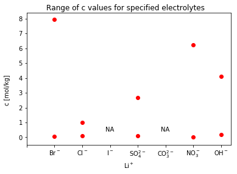

```python
# example call
plot_parameter_range(Li, "Li", parameter = "c")
```

```python
def plot_all_parameter_ranges(*data, parameter = "T"):
    """
    Extension of plot_parameter_range for more ions.
    Non named parameters are passed as follows:
    df_list_1, ..., df_list_N, ion_1, ..., ion_N
    """

    plot_for_all(*data, parameter=parameter,
                 function=plot_parameter_range)
```

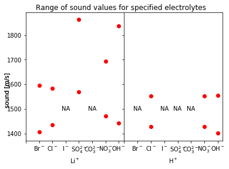

```python
# example call
plot_all_parameter_ranges(Li, H, "Li", "H", parameter = "sound")
```

### Boxplot plotting

Displays boxplot for selected parameter "T", "c" or "sound"

```python
def boxplot_parameter(df_list, ion, parameter="T", subplot = None):
    """
    Plots boxplots for paramater. df_list stores dataframes for ion.
    Figure axes can be passed through subplot parameter.
    """

    columns = []
    pair_ions = cation_anion_switch(ion)
    # number of datasets is set to number of counter ions
    # however in matrix plotting used later on only single electrolyte is plotted
    data_range = len(pair_ions) if len(df_list) > 1 else 1

    # coordinates for displaying NA values
    y = {"T":300, "sound":1500, "c":0.5}

    if subplot is None:
        fig, subplot = plt.subplots(ncols=1, nrows=1)

    for pos, (df, i) in enumerate(zip(df_list, pair_ions)):
        # plot NA for nonavailable dataset
        if df.empty == True:
            subplot.text(s="NA",x = pos+1, y=y[parameter],
                         horizontalalignment='center',
                         verticalalignment='center',color='k')
            columns.append([])
        else:
            # add values for available dataset so that boxplot can be plotted
            try:
                column = df[parameter]
            except:
                subplot.text(s="NA",x = pos+1, y=y[parameter],
                             horizontalalignment='center',
                             verticalalignment='center',color='k')
                columns.append([])
            else:
                columns.append(column)

    # plot the boxplots
    subplot.boxplot(columns, medianprops=dict(linestyle='-', color="r"))
    subplot.set_xticks(list(range(data_range+1)))

    # xticks are counter ion names
    labels = [""] + [chem_repr[i] for i in pair_ions]
    subplot.set_xticklabels(labels)
    subplot.set_xlabel(chem_repr[ion])

    # try to put graph title a y-axis label
    # it is not used in matrix plotting later on
    try:
        fig = plt.gcf()
        fig.suptitle("Boxplot of {0} dimension for specified electrolytes"
                     .format(parameter), y = 0.93)
        fig.text(0.04, 0.5, "{0} [{1}]"
                 .format(parameter, units[parameter]), rotation = 90)
    except:
        pass
```

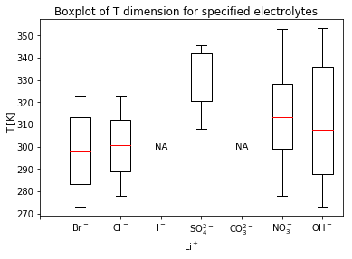

```python
# example call
boxplot_parameter(Li, "Li", parameter = "T")
```

```python
def boxplot_all_parameter(*data, parameter = "T"):
    """
    Extension of boxplot_parameter for more ions.
    Non named parameters are passed as follows:
    df_list_1, ..., df_list_N, ion_1, ..., ion_N
    """

    plot_for_all(*data, parameter = parameter,
                 function = boxplot_parameter)
```

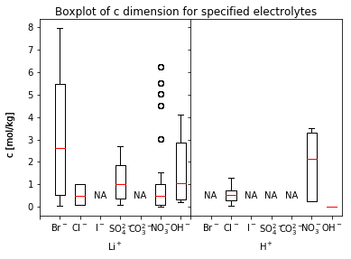

```python
# example call
boxplot_all_parameter(Li, H, "Li", "H", parameter = "c")
```

### Plots of speed of sound variation along different dimensions

Displays variation of speed of sound along either temperature of molality dimension

```python
def plot_sound(df_list, ion,*, parameter = "T",
               subplot = None, pair_ions = None):
    """
    Plots variation in speed of sound with parameter.
    df_list stores dataframes for ion.
    Figure axes can be passed through subplot parameter.
    The number of plotted
    electrolytes can be limited through setting pair_ions parameter
    to a list of counter ions.
    """
    ion_pairs = cation_anion_switch(ion)

    # list of colours so that every electrolyte has different color
    colors = ["r", "b", "k", "m", "c", "y", "orange"]

    # list designating if a counter ion will be plotted
    # here preset to all True in case pair_ions is not limited
    include = np.repeat(True, len(ion_pairs))

    if not pair_ions is None:
        include = [True if i in pair_ions else
                   False for i in ion_pairs]

    if subplot is None:
        fig, subplot = plt.subplots(nrows=1, ncols=1)

    # plot dataframe by dataframe
    for n, (df, i) in enumerate(zip(df_list, ion_pairs)):
        if df.empty == True:
            continue
        if include[n] == False:
            continue
        try:
            column = df[parameter]
        except:
            pass
        else:
            try:
                # groups dataframes by molality to disconnect unrelated data
                for name, group in df.groupby("c"):
                    # some dataframes have continuos molality change
                    # and are ploted as points
                    if group.shape[0] == 1:
                        lines, = subplot.plot(group[parameter].values,
                                              group["sound"].values,
                                              marker='o',markersize=1,
                                              color = colors[n])
                    else:
                        lines, = subplot.plot(group[parameter].values,
                                              group["sound"].values,
                                              linewidth = 2,
                                              color = colors[n])
                # every line is labeled by corresponding counter ion
                lines.set_label("{0}".format(chem_repr[i]))
            except:
                pass

    # x-label is the input ion
    subplot.set(xlabel="{0}".format(chem_repr[ion]))

    # put legend lowerleft
    if subplot.lines:
        subplot.legend(loc = 3)

    # in case of no data being plotted (missing dataframe in electrolyte matrix visualization)
    else:
        subplot.text(s="NA",x = 0.5, y=0.5,
                     horizontalalignment='center',
                     verticalalignment='center',color='k',
                     transform=subplot.transAxes)
```

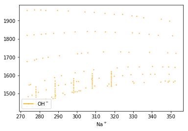

```python
# example call; NaOH dataset
plot_sound(Na, "Na", parameter = "T", pair_ions=["OH"])
```

```python
def plot_all_sound(*data, parameter="T"):
    """
    Extension of plot_sound for more ions.
    Non named parameters are passed as follows:
    df_list_1, ..., df_list_N, ion_1, ..., ion_N
    """
    plot_for_all(*data, parameter=parameter, function=plot_sound)
```

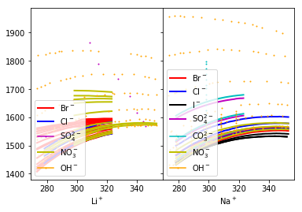

```python
# example call
plot_all_sound(Li, Na, "Li","Na", parameter = "T")
```

## Data visualization matrix

Type of visualization that using previously defined plotting visualizations shows data in the form of a matrix. Rows correspond to cations, while columns correspond to anions. Therefore each cell is an electrolyte.

```python
def plot_electrolyte_matrix(cations, anions, *data,
                            typ = "boxplot", parameter = "T"):
    """
    This function provides a way to visualize all electolyte data
    using matrix system.
    Cations forms rows, while anions form colums.
    In every cell data is plotted for corresponding eletrolyte
    using function provided in typ parameter.
    Calling: plot_electrolyte_matrix(cations,anions,
                                    *all_cation_dfs, **kwargs)
    """

    # check that accepted plotting type was used
    if not typ in ["boxplot", "range", "sound"]:
        print("Accepted types are: boxplot, range, sound")
        return

    # assign correct plot function
    if typ == "boxplot":
        plot_function = boxplot_parameter
    elif typ == "sound":
        plot_function = plot_sound
    elif typ == "range":
        plot_function = plot_parameter_range

    # matrix dimensions
    rows = len(cations)
    cols = len(anions)
    df_cations = data[:rows]

    # set fixed figure size
    plt.rcParams["figure.figsize"] = (2*cols,2*rows)
    fig, ax = plt.subplots(nrows = rows, ncols = cols,
                           sharey = True, sharex = True)

    # no white space between subplots
    plt.subplots_adjust(wspace = 0, hspace = 0)

    # plot row by row
    for row, (dfs, ion) in enumerate(zip(df_cations, cations)):
        for col, df in enumerate(dfs):
            plot_function([df], ion,
                          parameter = parameter,
                          subplot = ax[row][col])

            # remove legend created by plot_sound function
            if typ == "sound" and ax[row][col].lines:
                ax[row][col].get_legend().remove()

    # set cation / anion labels on y / x-axis
    for row in range(rows):
        ax[row][0].set_ylabel(chem_repr[cations[row]])
    for col in range(cols):
        ax[rows-1][col].set_xlabel(chem_repr[anions[col]])

        # remove x-ticks for boxplot and range type
        # (only sound has units there)
        if typ != "sound":
            ax[rows-1][col].set_xticks([])

    # add axis labels and title
    if typ == "sound":
        fig.suptitle("Matrix showing sound speed variation with {0}"
                     .format(parameter), y = 0.92)
        fig.text(0.05, 0.5, "Sound speed [m/s]", rotation=90)
        fig.text(0.5,0.04, "{0} [{1}]"
                 .format(parameter, units[parameter]))
    elif typ == "boxplot":
        fig.suptitle("Matrix showing boxplot for {0} parameter"
                     .format(parameter), y = 0.92)
    elif typ == "range":
        fig.suptitle("Matrix showing range of values for {0} parameter"
                     .format(parameter), y = 0.92)
    # reset matplotlib to default
    mpl.rcdefaults()
```

### Electrolyte matrix plots for all three visualizations and parameters

**Variation of speed of sound with temperature**

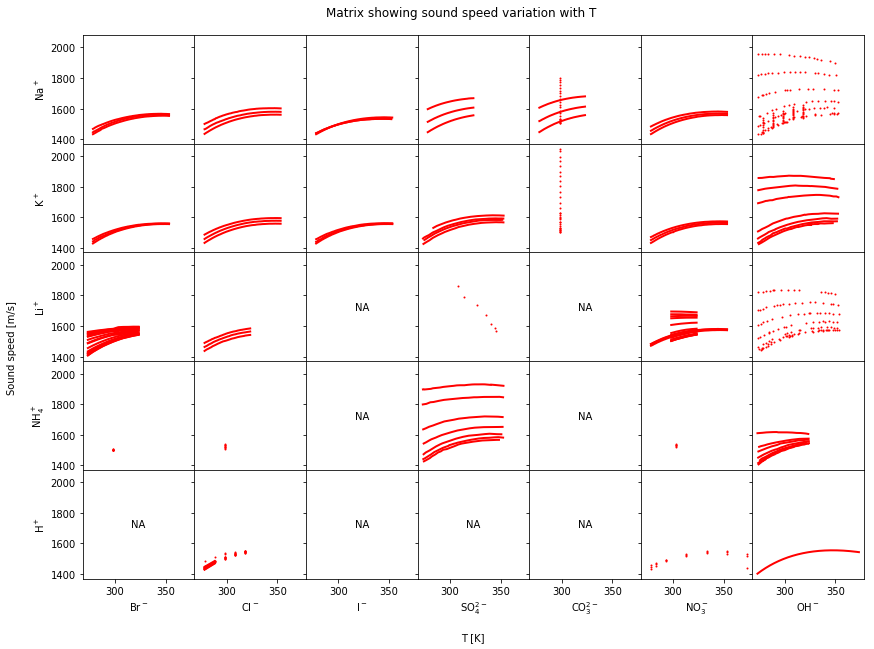

```python
plot_electrolyte_matrix(cations,anions, *all_cation_dfs, typ = "sound")
```

**Variation of speed of sound with molality**

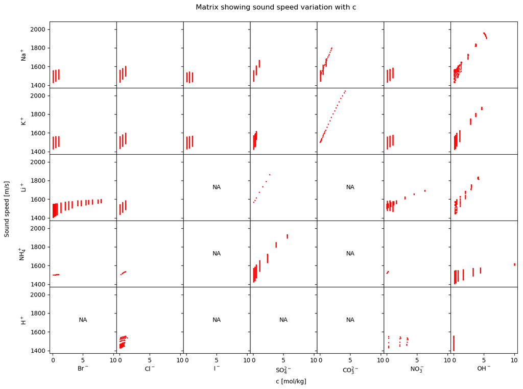

```python
plot_electrolyte_matrix(cations,anions, *all_cation_dfs,
                        typ = "sound", parameter = "c")
```

**Range of temperature values**

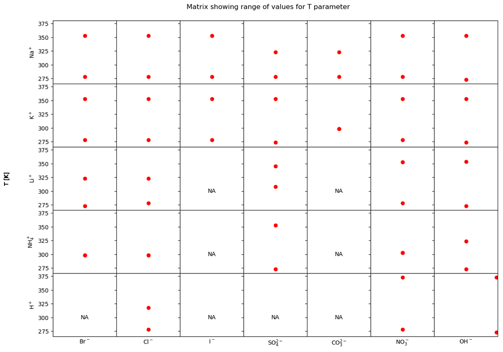

```python
plot_electrolyte_matrix(cations,anions, *all_cation_dfs, typ = "range")
```

**Range of molality values**

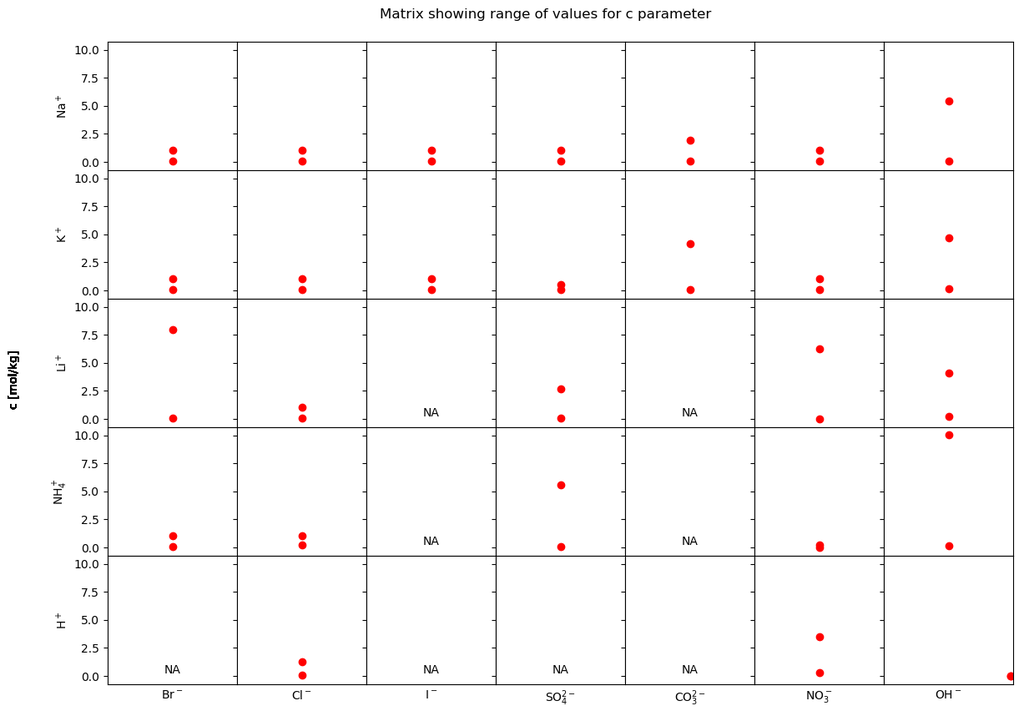

```python
plot_electrolyte_matrix(cations,anions, *all_cation_dfs,
                        typ = "range", parameter = "c")
```

**Range of sound speed values**

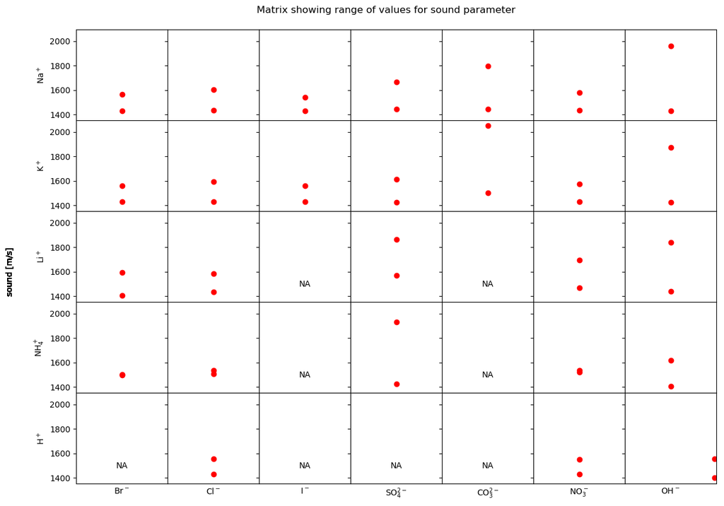

```python
plot_electrolyte_matrix(cations,anions, *all_cation_dfs,
                        typ = "range", parameter = "sound")
```

**Boxplot of temperature values**

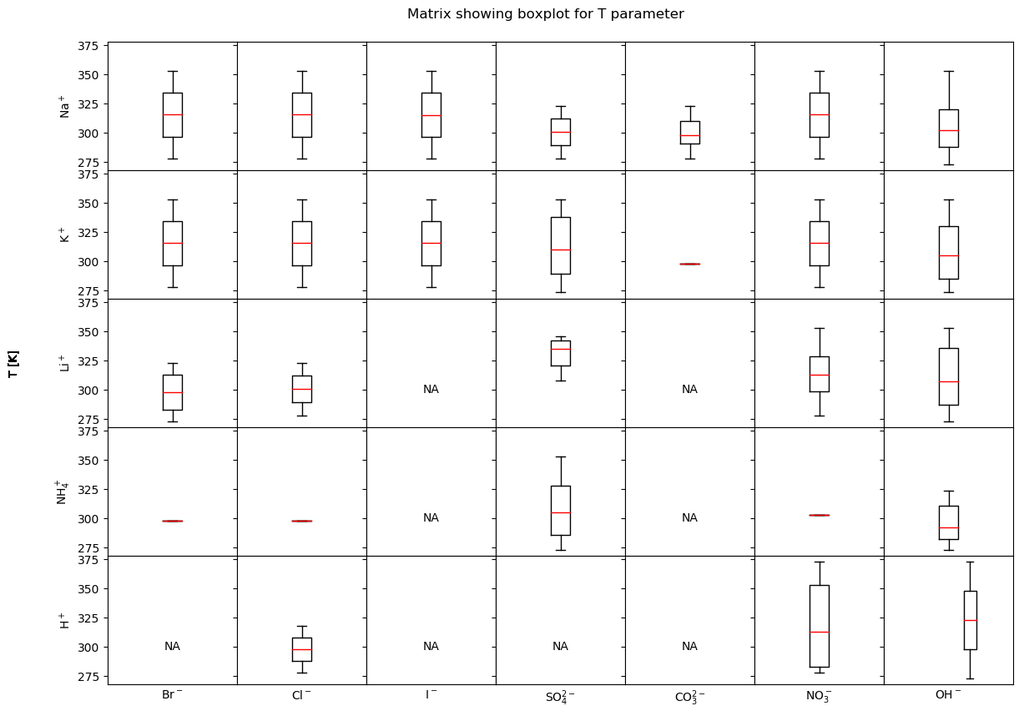

```python
plot_electrolyte_matrix(cations,anions,*all_cation_dfs,typ = "boxplot")
```

**Boxplot of molality values**

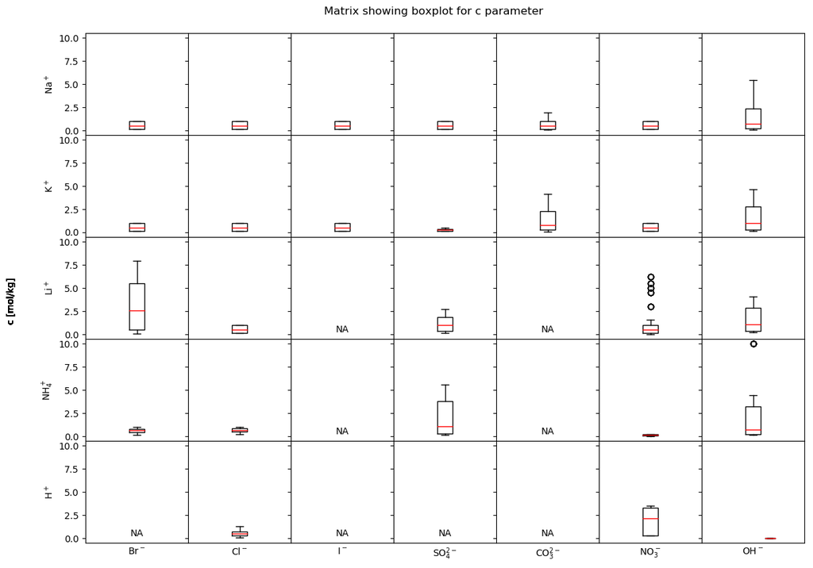

```python
plot_electrolyte_matrix(cations,anions, *all_cation_dfs,
                        typ = "boxplot", parameter = "c")
```

**Boxplot of sound speed values**

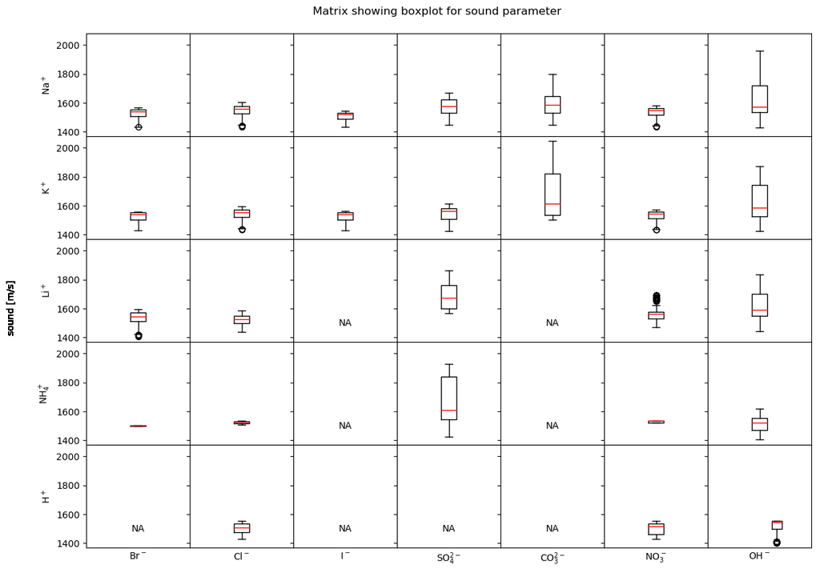

```python
plot_electrolyte_matrix(cations,anions, *all_cation_dfs,
                        typ = "boxplot", parameter = "sound")
```